# Introducción a ggplot2

Authors

Affiliations

Félix Belzunce

Universidad de Murcia

María del Carmen Bueso, Pilar Sanmartín

Universidad Politécnica de Cartagena

## Preliminares

- Creamos una carpeta `practicas` para nuestra asignatura
- Creamos tres subcarpetas: `data`, `src` y `figures`.
- En Rstudio, creamos el “proyecto” `fundamentos-inferencia`, asociado a la carpeta existente `practicas`.
- En `src`, creamos la carpeta `00-introduccion-a-ggplot`, y descargamos el fichero `introduccion_ggplot2.qmd` desde el aula virtual
- En `data`, descargamos el fichero `happy-ESS-2002-2020.csv` desde el aula virtual.
- Abrimos el fichero `introduccion_ggplot2.qmd` que hemos descargado en `00-introduccion-a-ggplot`.

## ggplot2: un paquete muy potente para gráficas en R

Utilizaremos la librería adicional `ggplot2`, cuyo autor es Hadley Wickham.

`gplot2` es una librería gráfica que

- Se rige por una “gramática”.
- Define componentes básicos que forman una frase.
- inspirada por “Grammar of graphics” por L. Wilkinson.
- Permite un gran rango de sofisticación: desde gráficas sencillas hasta gráficas muy complejas.

## Algunos recursos muy útiles

- https://ggplot2.tidyverse.org/index.html
- El libro [‘ggplot2: Elegant Graphics for Data Analysis’](https://ggplot2-book.org/) por Hadley Wickham, el creador de *ggplot2*
- El [sitio http://www.cookbook-r.com/Graphs/](http://www.cookbook-r.com/Graphs/) para el libro ‘Cookbook for R’

## Primeros pasos

Consideramos el siguiente dataframe para ilustración:

```r
df <- data.frame(
    col1 = c(3, 1, 5),
    col2 = c(2, 4, 6),
    col3 = c("a", "b", "c"),
    col4 = c("Hombre", "Mujer", "Hombre"),
    col5 = c(100, 300, 200)
)
```

Consta de tres filas, con cinco columnas: col1 hasta col5.

## La instrucción gráfica

Para producir una gráfica con ggplot2, la instrucción debe contener como mínimo dos componentes:

1. el componente básico `ggplot`
2. un `geom` (a menudo contendrá más de uno)

Por ejemplo:

```r
library(ggplot2)

ggplot(data = df, aes(x = col1, y = col2)) +
  geom_point()
```

o bien usando un “pipe”:

```r
df |>
  ggplot(aes(x = col1, y = col2)) +
  geom_point()
```

## El componente básico `ggplot`

En `ggplot`, se especifica en general como mínimo

- el dataframe que contiene las variables que queremos representar (el argumento es `data=`)
- algunos “aesthetics” básicos …

## The “aesthetics”: `aes` Un concepto fundamental

- en el argumento `aes` especificamos *todos los componentes de una gráfica que estén definidas por los valores de alguna columna del dataframe*. Por ejemplo, con `x = ...` especificamos qué variable del data.frame sirve para constuir el eje OX.
- Los “aesthetics” pueden especificar más que solo los ejes: forma, tamaño, transparencia(alfa), color, relleno, tipo de línea

## El componente básico `ggplot`, ejemplos con aesthetics

Representamos la columna `col3` en función de `col2`:

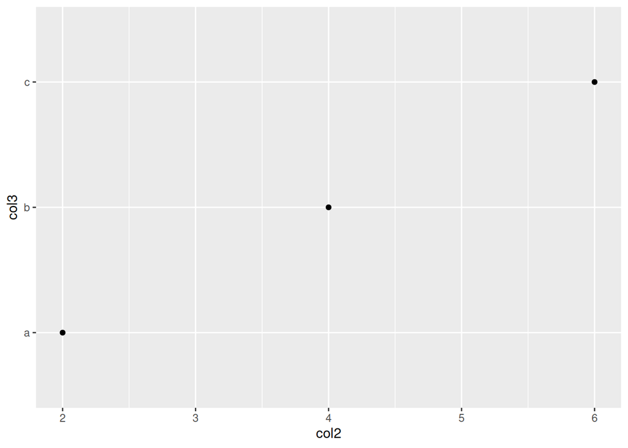

```r
ggplot(data = df, aes(x = col2, y = col3)) +
  geom_point()
```

## El componente básico `ggplot`, ejemplos con aesthetics

Usamos un color diferente según los valores que toma `col4`.

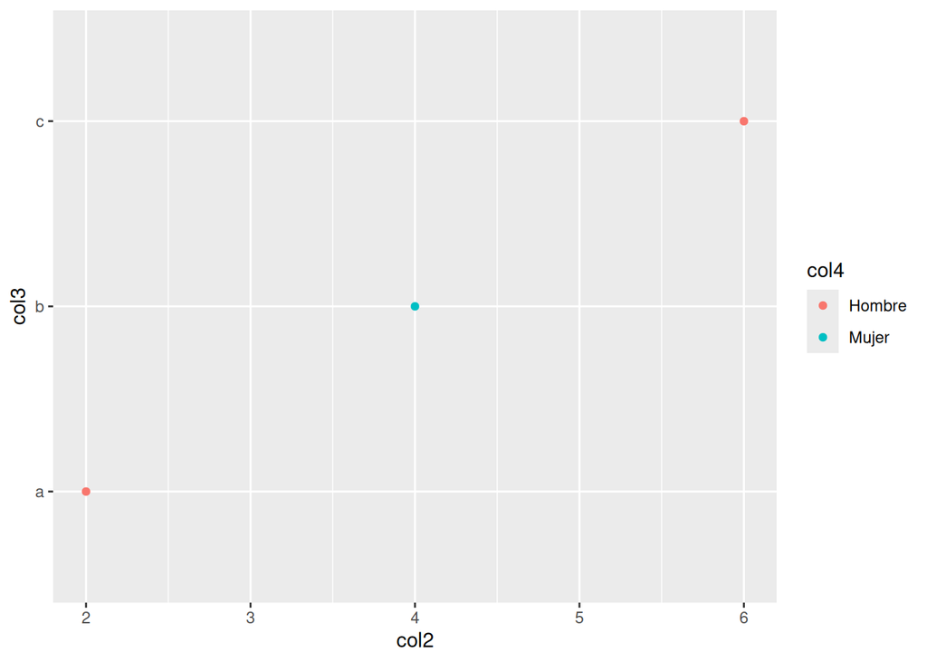

```r
ggplot(data = df, aes(x = col2, y = col3, color = col4)) +
  geom_point()
```

## El componente básico `ggplot`, ejemplos con aesthetics

Y además, una símbolo diferente según los valores de `col4`

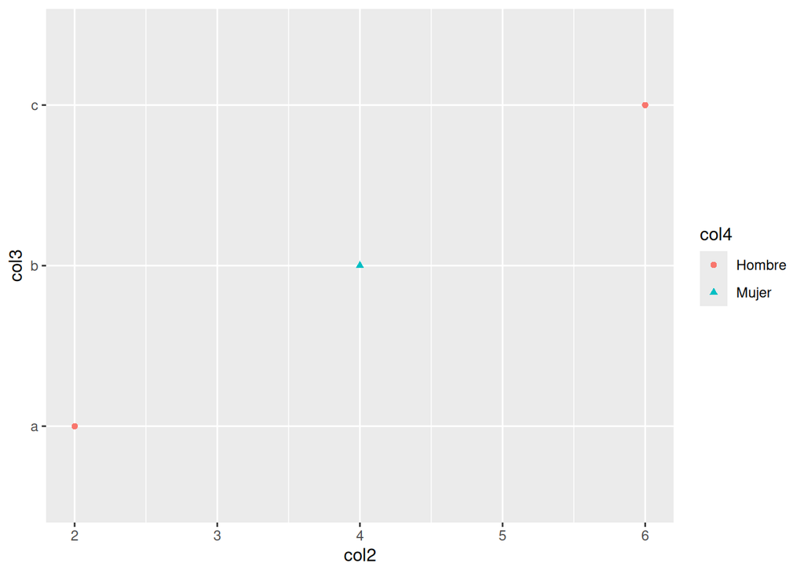

```r
ggplot(data = df, aes(x = col2, y = col3, color = col4, shape = col4)) +
  geom_point()
```

## El componente básico `ggplot`, ejemplos con aesthetics

Variando el tamaño de los puntos, según el valor de `col5`.

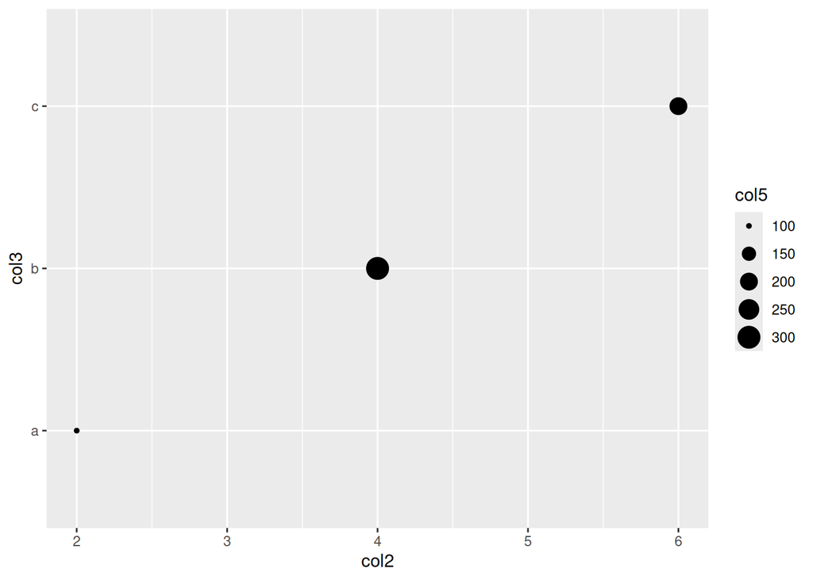

```r
ggplot(data = df, aes(x = col2, y = col3, size = col5)) +
  geom_point()
```

## Tengamos en cuenta

- Todos los geoms heredan de los `data` y los `aes` definidos en el componente básico `ggplot`.
- Pero podemos imponer unos nuevos a nivel de cada geom si nos interesa, con los mismos argumentos `data =` y `aes()`.
- Si queremos fijar un valor concreto para el color, tamaño, forma etc…, lo hacemos en el `geom`, directamente, fuera del argumento `aes` (recordar que éste se usa solo cuando la característica estética depende de una columna en el data frame.)

Fijamos el tamaño de los símbolos a 5:

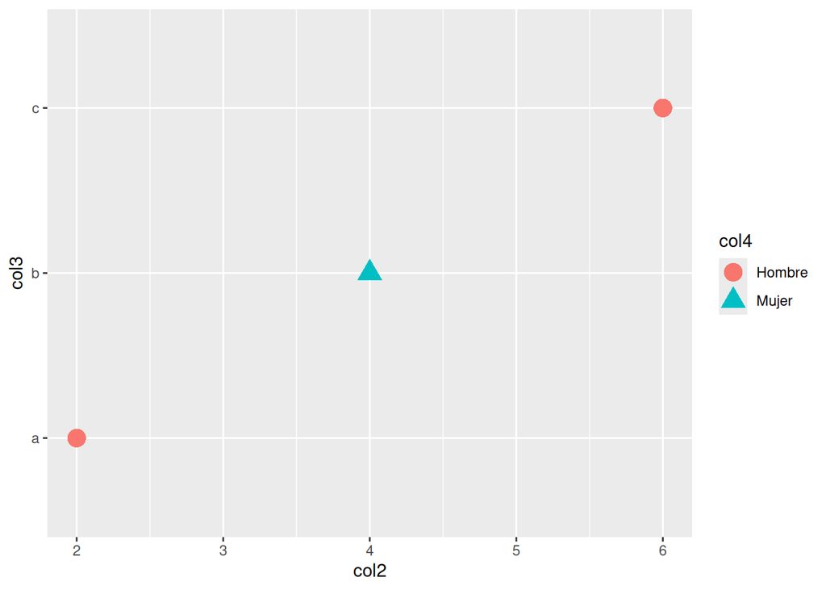

```r
ggplot(data = df, aes(x = col2, y = col3, color = col4, shape = col4)) +
  geom_point(size = 5)
```

## Probando otros `geoms`

Para empezar, podemos guardar en un objeto llamado $p$ el componente básico.

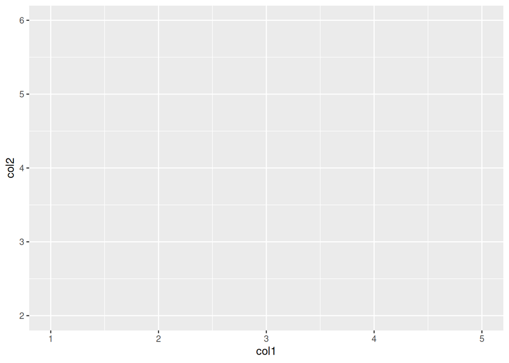

```r
p <- ggplot(data = df, aes(x = col1, y = col2))
p
```

y probamos con otros `geoms`:

```r
p + geom_point()
```

[output not shown]

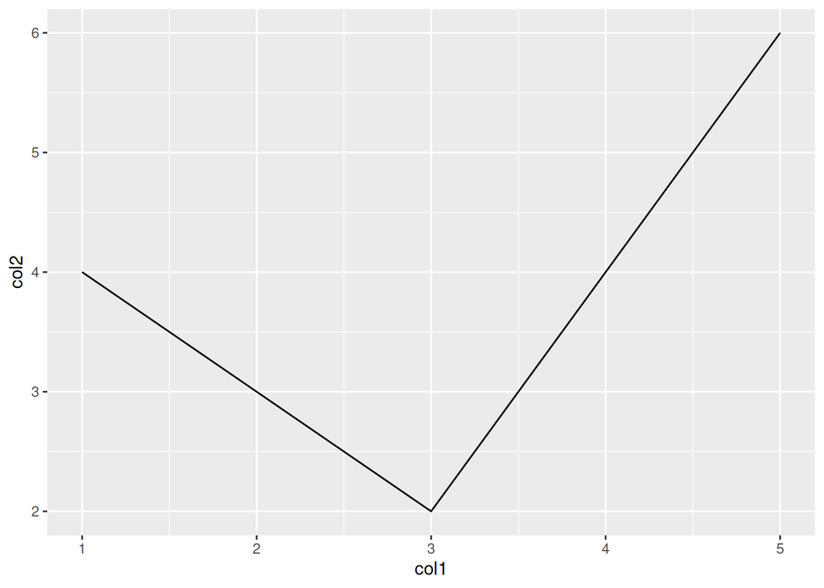

```r
p + geom_line()
```

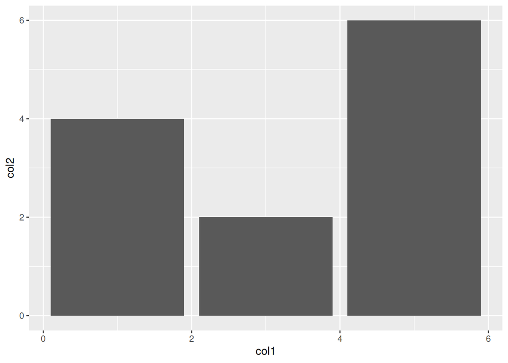

```r
p + geom_col()
```

## Para cambiar los rangos de valores representados en Ox y Oy

Usamos por ejemplo (hay otras opciones) la instrucciones [xlim](https://ggplot2.tidyverse.org/reference/lims.html) e [ylim](https://ggplot2.tidyverse.org/reference/lims.html)

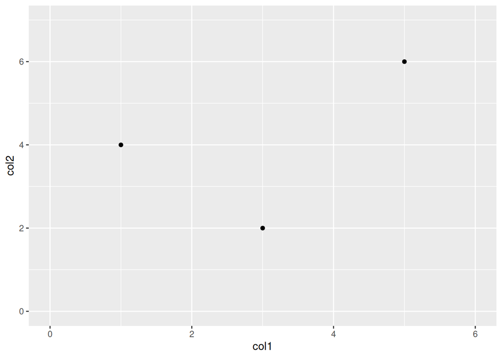

```r
p + geom_point() +
  xlim(0, 6) +
  ylim(0, 7)
```

Si estamos ya decididos a que éstos sean los valores límites para los ejes, lo podemos incluir en la definición de `p`

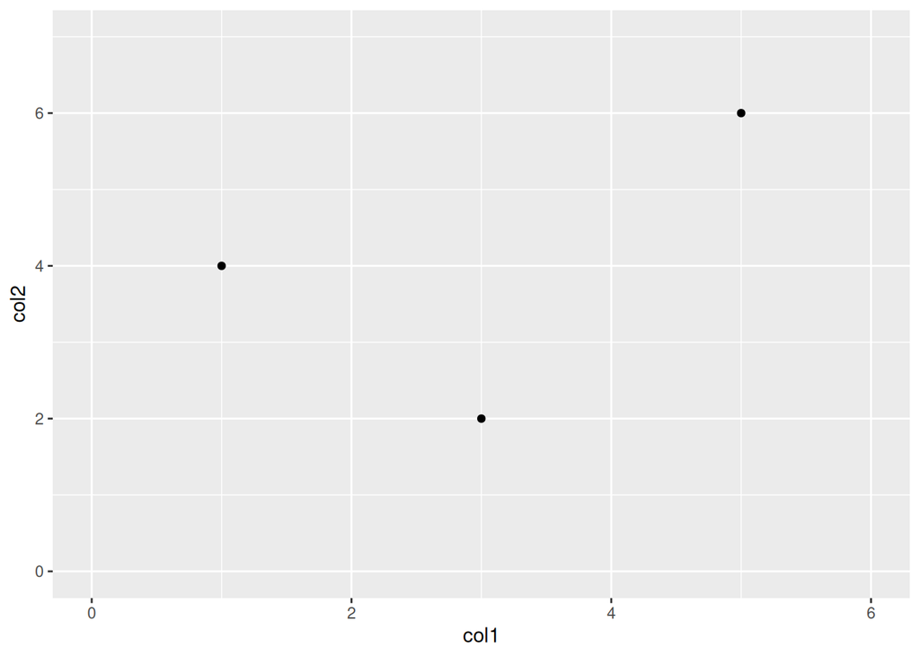

```r
p <- ggplot(data = df, aes(x = col1, y = col2)) +
  xlim(0, 6) +
  ylim(0, 7)

p + geom_point()
```

## Para cambiar ejes e incluir un título

Usamos la instrucción [labs](https://ggplot2.tidyverse.org/reference/labs.html).

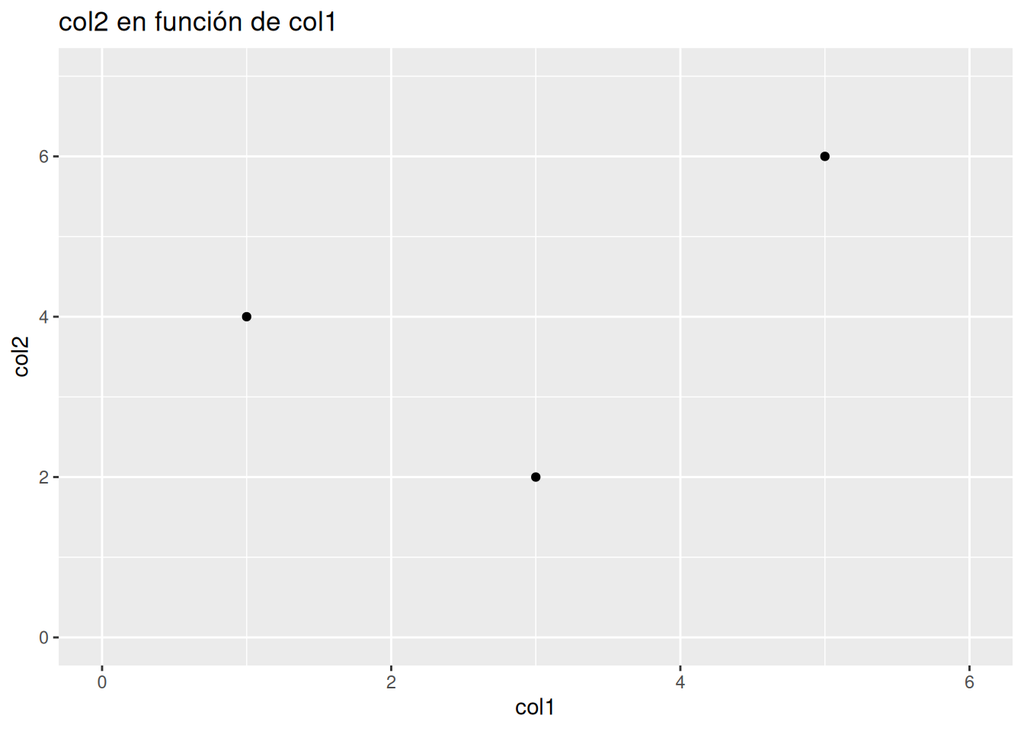

```r
p + geom_point() +
  labs(
    x = "col1",
    y = "col2",
    title = "col2 en función de col1"
  )
```

Todo es configurable en una gráfica con `ggplot2`, para cambiar fuente, tamaño, colores de las etiquetas de ejes, título, etc…, todo está centralizado en la instrucción [theme](https://ggplot2.tidyverse.org/reference/theme.html).

Por ejemplo

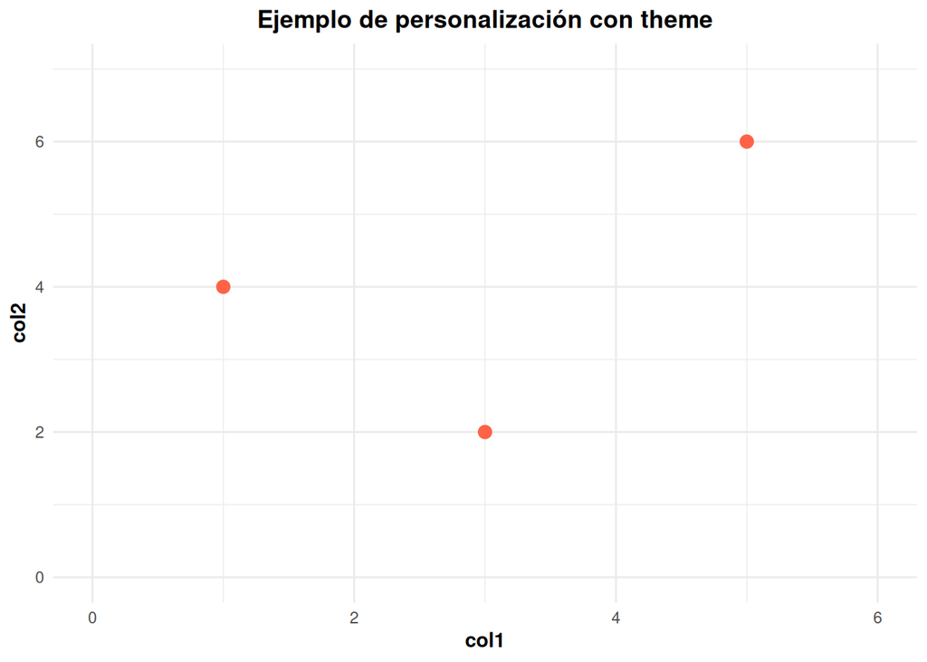

```r
p + geom_point(size = 3, color = "tomato") +
  labs(
    x = "col1",
    y = "col2",
    title = "Ejemplo de personalización con theme",
  ) +
  theme_minimal() +
  theme(
    plot.title = element_text(face = "bold", hjust = 0.5),
    axis.title = element_text(face = "bold")
  )
```

## Un ejemplo para ir practicando

Cada dos años, se realiza desde 2002 una gran encuesta llamada [European Social Survey](http://www.europeansocialsurvey.org/) cuyo objetivo es medir las actitudes, creencias y patrones de comportamiento de las poblaciones de más de 30 naciones.

Preguntan muchísimas cosas, una de las preguntas es

“Are you happy?”

a la que pueden contestar desde 0 (“Extremely unhappy”) a 10 (“Extremely happy”).

## Los datos

En el fichero ‘happy-ESS-2002-2020.csv’ están los datos que usaremos y que, después de importar se presentan así:

```r
happy  <- read.csv(file = "data/happy-ESS-2002-2020.csv", sep = ";")

head(happy)
```

```
  country year    n     mean       sd
1 Austria 2002 2246 7.570000 1.986609
2 Austria 2004 2236 7.493000 1.901890
3 Austria 2006 2377 7.444000 1.975385
4 Austria 2014 1795 7.508635 4.298156
5 Austria 2016 2010 7.884577 5.292783
6 Austria 2018 2499 8.062025 4.759525
```

```r
str(happy)
```

```
'data.frame':   255 obs. of  5 variables:
 $ country: chr  "Austria" "Austria" "Austria" "Austria" ...
 $ year   : int  2002 2004 2006 2014 2016 2018 2002 2004 2006 2008 ...
 $ n      : int  2246 2236 2377 1795 2010 2499 1891 1775 1797 1757 ...
 $ mean   : num  7.57 7.49 7.44 7.51 7.88 ...
 $ sd     : num  1.99 1.9 1.98 4.3 5.29 ...
```

- La columna `mean` contiene la valoración media del pais (de 0 a 10).
- La columna `sd` la desviación típica de las respuestas de este país.
- `n` contiene el número de entrevistados

## Primera exploración para España

Queremos una gráfica de la evolución temporal de la percepción de la felicidad en España…

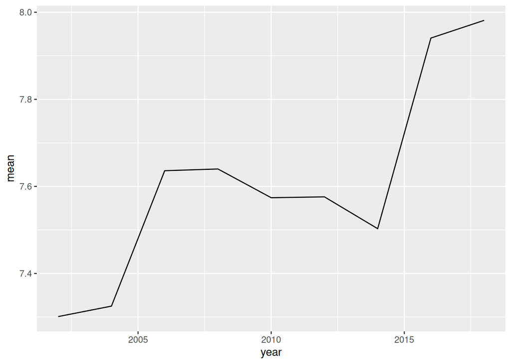

```r
happy_spain <- subset(happy, country == "Spain")

ggplot(data = happy_spain, aes(x = year, y = mean)) +
  geom_line()
```

**WarningEjercicio**

¿Podéis mejorarlo, añadiendo puntos también, cambiando los límites del eje Oy y cambiando el color de las líneas y de los puntos?

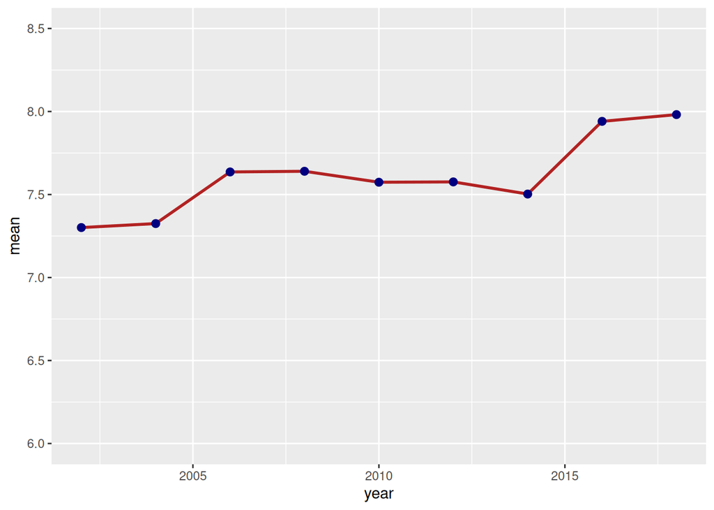

```r
happy_spain <- subset(happy, country == "Spain")

ggplot(data = happy_spain, aes(x = year, y = mean)) +
  geom_line(color = "firebrick", linewidth = 1) +
  geom_point(color = "navy", size = 2.3) +
  coord_cartesian(ylim = c(6, 8.5))
```

## Añadimos países

Queremos ahora comparar España a varios países del entorno, en concreto, con el “Total”, Alemania, Francia y Reino Unido.

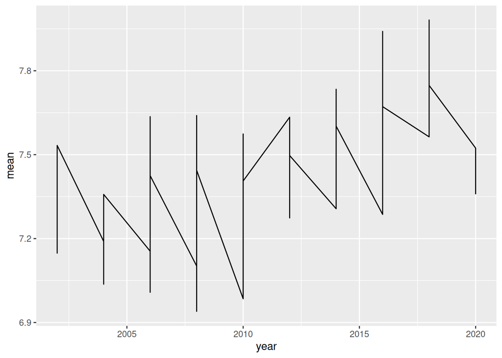

```r
happy_compare <- subset(
  happy,
  country %in% c("Total", "Germany", "France", "United Kingdom", "Spain")
)

ggplot(data = happy_compare, aes(x = year, y = mean)) +
  geom_line()
```

¿Era ésta la gráfica que esperábais?

## Añadimos países

Necesitamos especificar un “aesthetic” que esté asociado a country, para poder visualizar las diferencias entre los países.

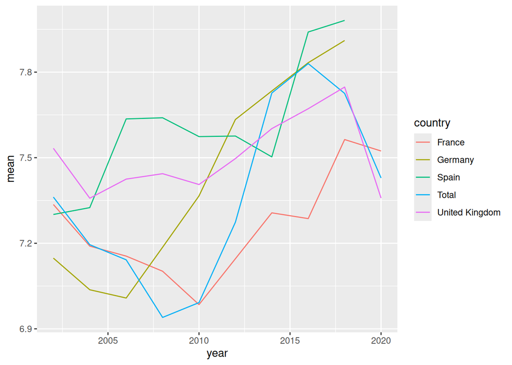

```r
gghappiness <- ggplot(
  data = happy_compare,
  aes(x = year, y = mean, color = country, group = country)
) +
  geom_line()

gghappiness
```

**WarningEjercicio**

- ¿Podríais añadir puntos, cambiar también el tipo de línea?(ver documentación de `geom_line` en [enlace documentación](https://ggplot2.tidyverse.org/reference/geom_path.html)
- Guardamos el objeto gráfico correspondiente en `gghappiness`.

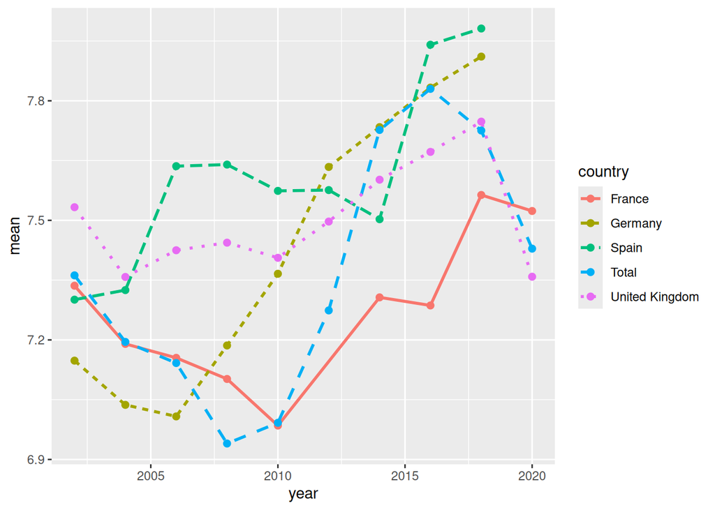

```r
happy_compare <- subset(
  happy,
  country %in% c("Total", "Germany", "France", "United Kingdom", "Spain")
)

gghappiness <- ggplot(
  data = happy_compare,
  aes(x = year, y = mean, color = country, linetype = country, group = country)
) +
  geom_line(linewidth = 1) +
  geom_point(size = 2)

gghappiness
```

## El comando `facet_grid`

El comando `facet_grid` permite crear una matriz de gráficas especificando una variable que defina las filas y otra que defina las columnas.  
Concretamente,

`facet_grid(X ~ Y)`

crea una matriz de gráficas por grupos, donde cada fila agrupa a valores de `X` distintos, mientras que cada columna agrupa a valores de `Y` distintos.  
Si queremos una única fila o una única columna, usamos un punto para la variable correspondiente en `facet_grid`, por ejemplo, una fila y varias columnas:

`facet_grid(. ~ Y)`

## Ejercicio

**WarningEjercicio**

Representar la evaluación anual de la percepción promedio de la felicidad en tres gráficas en una fila para España, Francia y Reino Unido.

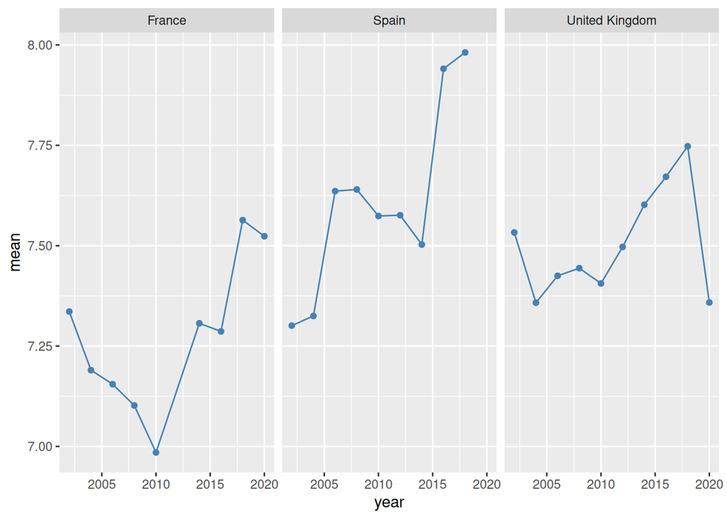

```r
happy_facet  <- subset(
  happy,
  country %in% c("Spain", "France", "United Kingdom")
)

ggplot(data = happy_facet, aes(x = year, y = mean)) +
  geom_line(color = "steelblue") +
  geom_point(color = "steelblue") +
  facet_grid(. ~ country)
```